# Accessibility with R5R - Tutorial

Saraiva, Marcus

28/02/2022

## Introduction

Accessibility metrics measure the ease with which opportunities, such as jobs, healthcare, and education facilities, can be reached by a traveler from a particular location.

One of the simplest forms of accessibility metrics is the cumulative-opportunities, which counts all of the opportunities accessible from each location in less than a cutoff time.

This tutorial shows how to calculate accessibility metrics in R using the free and open-source [`r5r` package](https://ipeagit.github.io/r5r/index.html). `r5r` provides a simple and friendly interface to R5, a very fast and open source Java-based multi-modal routing engine developed by [Conveyal](https://www.conveyal.com/). R5 stands for [Rapid Realistic Routing on Real-world and Reimagined networks](https://github.com/conveyal/r5).

In this example, we will be using a subset of the Greater London Authority (GLA) area comprised by London’s Inner Boroughs.

## Obtaining the input data

Two input datasets are required to build a multi-modal transport network:

1. road network dataset from OpenStreetMap, used for routing of walking, cycling and driving trips, as well as access to public transport stations and stops;
2. public transport schedules in GTFS format;

Both datasets are freely available for the Greater London Authority area. The road network can be downloaded from Geofabrik daily extracts, and London’s GTFS feeds are provided by the UK’s [Department for Transportation](https://data.bus-data.dft.gov.uk/) open data portal.

We also need information on the location and number of opportunities in the study area, as well as the geographic locations of places where people live and that we want to evaluate. The data used in this tutorial, in geopackage format, is provided in the `data_inner` folder of this repository. There are two files in that folder:

1. `od_zones_inner_gla.gpkg`: MSOA zones of inner London boroughs;
2. `od_points_inner_gla.gpkg`: lat/lon coordinates of the centroids of the MSOAs.

The following sections will show how to load those datasets and calculate the accessibility at London’s MSOAs.

## Setup and Initialisation

### Load necessary libraries

Before we start using `r5r`, we need to increase the memory available to Java. This is necessary because, by default, `R` allocates only 512MB of memory for Java processes, which is not enough for large queries using `r5r`. To increase available memory to 6GB, for example, we need to set the `java.parameters` option, as follows:

```r
options(java.parameters = "-Xmx6G")
```

Then we can load the packages used in this tutorial:

```r
library(r5r)
library(tidyverse)
library(sf)
library(data.table)
library(ggplot2)
library(mapview)
```

### Load input data

The centroids dataset (`od_points_sf`) contains the following required fields:

1. id: unique identifier of each location;
2. jobs: number of jobs in each location (obs: any kind of opportunity can be considered, not neccessarily jobs);
3. geom: the POINT geometry of each location, in WGS 84 CRS.

The code below shows the contents of `od_points_sf`:

```r
od_points_sf
```

```
## Simple feature collection with 393 features and 2 fields
## Geometry type: POINT
## Dimension:     XY
## Bounding box:  xmin: -0.2480932 ymin: 51.41451 xmax: 0.1162393 ymax: 51.57346
## Geodetic CRS:  WGS 84
## First 10 features:
##           id   jobs                         geom
## 1  E02000001 356527 POINT (-0.09041453 51.51426)
## 2  E02000166   2121  POINT (-0.1540669 51.56412)
## 3  E02000167   2669  POINT (-0.1728825 51.56106)
## 4  E02000168   4443  POINT (-0.1409897 51.55487)
## 5  E02000169   1182  POINT (-0.1848507 51.55616)
## 6  E02000170   1313  POINT (-0.1997927 51.55366)
## 7  E02000171   1342  POINT (-0.1573627 51.55168)
## 8  E02000172   4138   POINT (-0.1462734 51.5493)
## 9  E02000173   9903  POINT (-0.1718277 51.54978)
## 10 E02000174   2134  POINT (-0.1343495 51.54846)
```

### Visualising input data

We can use the `mapview` package to open an interactive map of the input points:

```r
mapview(od_points_sf)
```

[interactive chart not shown]

## Calculating and visualising accessibility

### Calculating accessibility

Now that everything is in place, we can compute accessibility to jobs with a single line of R code:

```r
access_df <- accessibility(r5r_core,
                           origins = od_points_sf,
                           destinations = od_points_sf,
                           opportunities_colname = "jobs",
                           mode = c("WALK", "TRANSIT"),
                           departure_datetime = as.POSIXct("02-03-2022 09:00:00",
                                                           format = "%d-%m-%Y %H:%M:%S"),
                           cutoffs = c(30, 45),
                           verbose = FALSE,
                           progress = TRUE)
```

```
## Preparing final output... DONE!
```

The `accessibility` function above takes the following parameters:

- `r5r_core`: the variable created by `setup_r5` that contains the R5 routing network and engine in memory;
- `origins` and `destinations`: the points representing origins and destinations of trips.
- `opportunities_colname`: the name of the column in the `destination` points dataset that contains the opportunities we are calculating access to (in this case, `jobs`);
- `mode`: transport modes to be considered, where `TRANSIT` includes all modes of public transportation (such as busses, the underground, commuter trains, and so on);
- `departure_datetime`: the day and time of the start of the trips. For public transport trips, the date must be inside the range available in the GTFS data provided.
- `cutoffs`: the travel times, in minutes, that we are calculating cumulative- opportunities accessibility metrics.
- `verbose = FALSE`: reduces the amountof outputs to the R console;
- `progress = TRUE`: shows the progress of the calculation;

### Visualising results

Finally, to see the results, we need to join the results of the `accessibility` function with the geometry of the input zones. This can be done in R as well:

```r
access_sf <- left_join(od_zones, access_df, by = c("code"="from_id"))
```

We can plot the results and visualise how many jobs people can access in 30 and 45 minutes of travel time, using London’s public transport system.

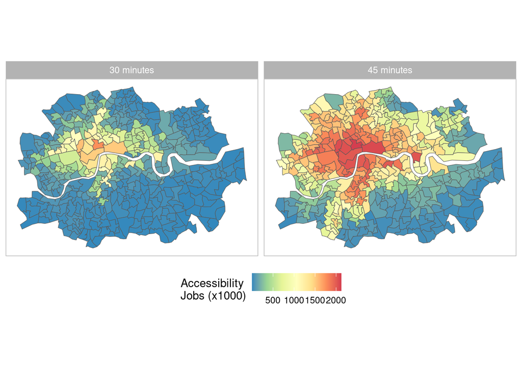

```r
access_sf %>%
  ggplot(aes(fill=accessibility/1000)) +
  geom_sf(aes(geometry=geom), size=0.2) +
  coord_sf(datum=NA) +
  scale_fill_distiller(palette = "Spectral") +
  labs(fill = "Accessibility\nJobs (x1000)") +
  theme_light() +
  theme(legend.position = "bottom") +
  facet_wrap(~cutoff, labeller = labeller(cutoff = function(s) return(paste(s, "minutes"))))
```